# LTCMarkdown

SamJohnson

2022-08-28

## Litecoin Analysis

This Analysis will cover why Litecoin is a successful cryptocurrency and educate you on its potential. This is not financial advice. Please do your own research.  
Litecoin is a cryptocurrency running on a Proof of Work blockchain. Charlie Lee, an ex-Google engineer and former employee of Coinbase founded the project to solve some of the problems that Bitcoin had been going through. It is commonly merge-mined with Dogecoin since both of them run the Script algorithm. However, unlike the inflationary Dogecoin, Litecoin has a set cap of 84 million and a halving cycle every four years, much like Bitcoin.  
Unlike Bitcoin though, Litecoin creates blocks every 2.5 minutes instead of Bitcoin’s 10. This lighter algorithm and faster block time make Litecoin an ideal currency for quick and hard transactions. Additionally, Litecoin acts like a test network for Bitcoin, having implemented the Mimble Wimble privacy protocol before Bitcoin as well as the Lightning Network among other projects.  
Furthermore, wherever Bitcoin is sold, Litecoin is also. This crypto surely represents Digital Silver if Bitcoin is Digital Gold.

```
## Rows: 2,991
## Columns: 10
## $ SNo       <dbl> 1, 2, 3, 4, 5, 6, 7, 8, 9, 10, 11, 12, 13, 14, 15, 16, 17, 1…
## $ Name      <chr> "Litecoin", "Litecoin", "Litecoin", "Litecoin", "Litecoin", …
## $ Symbol    <chr> "LTC", "LTC", "LTC", "LTC", "LTC", "LTC", "LTC", "LTC", "LTC…
## $ Date      <dttm> 2013-04-29 23:59:59, 2013-04-30 23:59:59, 2013-05-01 23:59:…
## $ High      <dbl> 4.57360, 4.57238, 4.35686, 4.03930, 3.45361, 3.63828, 3.6924…
## $ Low       <dbl> 4.22564, 4.16896, 3.52029, 3.00717, 2.39594, 2.89525, 3.3460…
## $ Open      <dbl> 4.36676, 4.40352, 4.28954, 3.78002, 3.39044, 3.03227, 3.4931…
## $ Close     <dbl> 4.38390, 4.29649, 3.80101, 3.37198, 3.04491, 3.47962, 3.5908…
## $ Volume    <dbl> 0, 0, 0, 0, 0, 0, 0, 0, 0, 0, 0, 0, 0, 0, 0, 0, 0, 0, 0, 0, …
## $ Marketcap <dbl> 75388964, 74020918, 65604596, 58287979, 52694847, 60290868, …
```

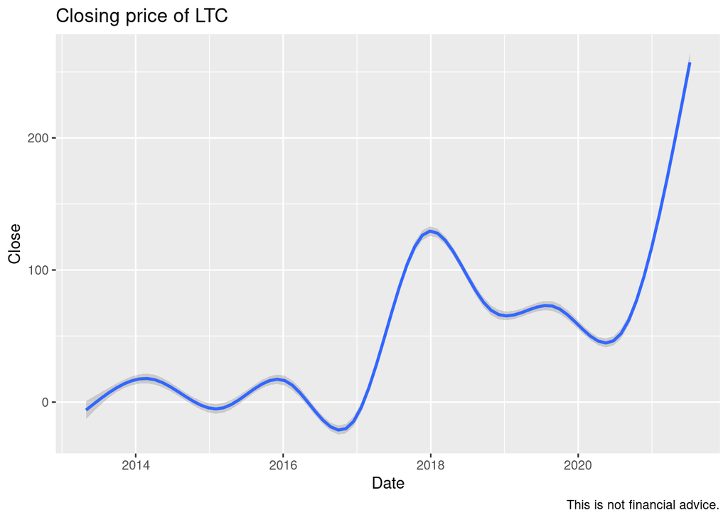